# Tugas Akhir Individu TPG

Nisrina Suci Fadila (G1401231021)

2025-11-26

```r
library(tidyverse)
library(readxl)
library(lubridate)
library(janitor)
library(imputeTS)
library(factoextra)
library(cluster)
library(dtwclust)
library(scales)
library(patchwork)
```

```r
library(dplyr)
library(tidyr)
library(ggplot2)
library(tsibble)
library(feasts)
library(TSclust)
library(dtwclust)
library(dtw)
```

# 1. Import Data

```r
data <- read_xlsx("D:\\semester 5\\TPG\\0_df_long.xlsx")
head(data)
```

```
## # A tibble: 6 × 9
##   KabKot          Tahun Bulan   Produk  Harga Kategori KodeBPS KodeProv NamaProv
##   <chr>           <dbl> <chr>   <chr>   <chr> <chr>      <dbl>    <dbl> <chr>
## 1 Kab. Aceh Barat  2022 Januari Beras … 11429 Beras       11.0       11 Aceh
## 2 Kab. Aceh Barat  2022 Januari Beras … 9979  Beras       11.0       11 Aceh
## 3 Kab. Aceh Barat  2022 Januari Bawang… 31000 Bawang      11.0       11 Aceh
## 4 Kab. Aceh Barat  2022 Januari Bawang… 28636 Bawang      11.0       11 Aceh
## 5 Kab. Aceh Barat  2022 Januari Cabai … 19409 Cabai       11.0       11 Aceh
## 6 Kab. Aceh Barat  2022 Januari Cabai … 45706 Cabai       11.0       11 Aceh
```

# 2. Pre Processing Data

## a. Filter Data

```r
dt_jabar <- data %>%
  filter(NamaProv == "Jawa Barat")
```

```r
dt_jabar_cabai <- dt_jabar %>%
  filter(Kategori == "Cabai")
```

```r
dt_jabar_cabai <- dt_jabar %>%
  filter(Produk == "Cabai Merah Besar")
```

```r
dt_jabar_cabai2 <- dt_jabar_cabai %>%
  filter(Tahun >= 2025)
head(dt_jabar_cabai2)
```

```
## # A tibble: 6 × 9
##   KabKot       Tahun Bulan    Produk    Harga Kategori KodeBPS KodeProv NamaProv
##   <chr>        <dbl> <chr>    <chr>     <chr> <chr>      <dbl>    <dbl> <chr>
## 1 Kab. Bandung  2025 Januari  Cabai Me… 67016 Cabai       32.0       32 Jawa Ba…
## 2 Kab. Bandung  2025 Februari Cabai Me… 48197 Cabai       32.0       32 Jawa Ba…
## 3 Kab. Bandung  2025 Maret    Cabai Me… 45345 Cabai       32.0       32 Jawa Ba…
## 4 Kab. Bandung  2025 April    Cabai Me… 37265 Cabai       32.0       32 Jawa Ba…
## 5 Kab. Bandung  2025 Mei      Cabai Me… 32705 Cabai       32.0       32 Jawa Ba…
## 6 Kab. Bandung  2025 Juni     Cabai Me… 65976 Cabai       32.0       32 Jawa Ba…
```

## b. Cek Tipe Data

```r
str(dt_jabar_cabai2)
```

```
## tibble [270 × 9] (S3: tbl_df/tbl/data.frame)
##  $ KabKot  : chr [1:270] "Kab. Bandung" "Kab. Bandung" "Kab. Bandung" "Kab. Bandung" ...
##  $ Tahun   : num [1:270] 2025 2025 2025 2025 2025 ...
##  $ Bulan   : chr [1:270] "Januari" "Februari" "Maret" "April" ...
##  $ Produk  : chr [1:270] "Cabai Merah Besar" "Cabai Merah Besar" "Cabai Merah Besar" "Cabai Merah Besar" ...
##  $ Harga   : chr [1:270] "67016" "48197" "45345" "37265" ...
##  $ Kategori: chr [1:270] "Cabai" "Cabai" "Cabai" "Cabai" ...
##  $ KodeBPS : num [1:270] 32 32 32 32 32 ...
##  $ KodeProv: num [1:270] 32 32 32 32 32 32 32 32 32 32 ...
##  $ NamaProv: chr [1:270] "Jawa Barat" "Jawa Barat" "Jawa Barat" "Jawa Barat" ...
```

## c. Mengubah Format Tanggal

```r
dt_jabar_cabai2 <- dt_jabar_cabai2 %>%
  mutate(
    Bulan = str_squish(Bulan),
    Bulan = str_replace_all(Bulan, "[^[:alnum:]]", ""),
    Bulan = case_when(
      Bulan == "Januari" ~ 1,
      Bulan == "Februari" ~ 2,
      Bulan == "Maret" ~ 3,
      Bulan == "April" ~ 4,
      Bulan == "Mei" ~ 5,
      Bulan == "Juni" ~ 6,
      Bulan == "Juli" ~ 7,
      Bulan == "Agustus" ~ 8,
      Bulan == "September" ~ 9,
      Bulan == "Oktober" ~ 10,
      Bulan == "November" ~ 11,
      Bulan == "Desember" ~ 12,
      TRUE ~ NA_real_
    )
  )
```

```r
dt_jabar_cabai2 <- dt_jabar_cabai2 %>%
  mutate(Date = make_date(Tahun, Bulan, 1))
dt_jabar_cabai2
```

```
## # A tibble: 270 × 10
##    KabKot Tahun Bulan Produk Harga Kategori KodeBPS KodeProv NamaProv Date
##    <chr>  <dbl> <dbl> <chr>  <chr> <chr>      <dbl>    <dbl> <chr>    <date>
##  1 Kab. …  2025     1 Cabai… 67016 Cabai       32.0       32 Jawa Ba… 2025-01-01
##  2 Kab. …  2025     2 Cabai… 48197 Cabai       32.0       32 Jawa Ba… 2025-02-01
##  3 Kab. …  2025     3 Cabai… 45345 Cabai       32.0       32 Jawa Ba… 2025-03-01
##  4 Kab. …  2025     4 Cabai… 37265 Cabai       32.0       32 Jawa Ba… 2025-04-01
##  5 Kab. …  2025     5 Cabai… 32705 Cabai       32.0       32 Jawa Ba… 2025-05-01
##  6 Kab. …  2025     6 Cabai… 65976 Cabai       32.0       32 Jawa Ba… 2025-06-01
##  7 Kab. …  2025     7 Cabai… 60536 Cabai       32.0       32 Jawa Ba… 2025-07-01
##  8 Kab. …  2025     8 Cabai… 54941 Cabai       32.0       32 Jawa Ba… 2025-08-01
##  9 Kab. …  2025     9 Cabai… 79659 Cabai       32.0       32 Jawa Ba… 2025-09-01
## 10 Kab. …  2025    10 Cabai… 69247 Cabai       32.0       32 Jawa Ba… 2025-10-01
## # ℹ 260 more rows
```

```r
dt_jabar_cabai2 <- dt_jabar_cabai2 %>%
  arrange(KabKot, Date)
```

```r
dt <- dt_jabar_cabai2 %>%
  select(KabKot, Date, Produk, Harga)
head(dt)
```

```
## # A tibble: 6 × 4
##   KabKot       Date       Produk            Harga
##   <chr>        <date>     <chr>             <chr>
## 1 Kab. Bandung 2025-01-01 Cabai Merah Besar 67016
## 2 Kab. Bandung 2025-02-01 Cabai Merah Besar 48197
## 3 Kab. Bandung 2025-03-01 Cabai Merah Besar 45345
## 4 Kab. Bandung 2025-04-01 Cabai Merah Besar 37265
## 5 Kab. Bandung 2025-05-01 Cabai Merah Besar 32705
## 6 Kab. Bandung 2025-06-01 Cabai Merah Besar 65976
```

## d. Cek Missing Value

```r
glimpse(dt)
```

```
## Rows: 270
## Columns: 4
## $ KabKot <chr> "Kab. Bandung", "Kab. Bandung", "Kab. Bandung", "Kab. Bandung",…
## $ Date   <date> 2025-01-01, 2025-02-01, 2025-03-01, 2025-04-01, 2025-05-01, 20…
## $ Produk <chr> "Cabai Merah Besar", "Cabai Merah Besar", "Cabai Merah Besar", …
## $ Harga  <chr> "67016", "48197", "45345", "37265", "32705", "65976", "60536", …
```

```r
dt <- dt %>%
  mutate(
    Harga = as.numeric(Harga)
  )
summary(dt)
```

```
##     KabKot               Date               Produk              Harga
##  Length:270         Min.   :2025-01-01   Length:270         Min.   :18670
##  Class :character   1st Qu.:2025-03-01   Class :character   1st Qu.:41111
##  Mode  :character   Median :2025-05-16   Mode  :character   Median :49444
##                     Mean   :2025-05-17                      Mean   :49933
##                     3rd Qu.:2025-08-01                      3rd Qu.:59590
##                     Max.   :2025-10-01                      Max.   :79659
##                                                             NA's   :16
```

Hasil summary menunjukkan bahwa Terdapat 16 missing value pada kolom harga

```r
dt %>% group_by(KabKot, Produk) %>% summarise(NA_Harga = sum(is.na(Harga)))
```

```
## # A tibble: 27 × 3
## # Groups:   KabKot [27]
##    KabKot             Produk            NA_Harga
##    <chr>              <chr>                <int>
##  1 Kab. Bandung       Cabai Merah Besar        0
##  2 Kab. Bandung Barat Cabai Merah Besar        0
##  3 Kab. Bekasi        Cabai Merah Besar        0
##  4 Kab. Bogor         Cabai Merah Besar        0
##  5 Kab. Ciamis        Cabai Merah Besar       10
##  6 Kab. Cianjur       Cabai Merah Besar        0
##  7 Kab. Cirebon       Cabai Merah Besar        0
##  8 Kab. Garut         Cabai Merah Besar        0
##  9 Kab. Indramayu     Cabai Merah Besar        0
## 10 Kab. Karawang      Cabai Merah Besar        0
## # ℹ 17 more rows
```

Setelah dilakukan pengecekan letak missing value, hasil menunjukkan terdapat 10 missing value harga cabai merah besar pada Kab. Ciamis dan 6 missing value harga cabai merah besar pada Kab. Pangandaran

## e. Imputasi Missing Value (NA)

```r
## Tahap 1: Imputasi dengan Rata-rata PRODUK

mean_produk <- dt %>%
  group_by(Produk) %>%
  summarise(mean_harga_produk = mean(Harga, na.rm = TRUE)) %>%
  ungroup()

dt_imputasi <- dt %>%
  left_join(mean_produk, by = "Produk") %>%
  mutate(

    Harga_Imputasi = ifelse(is.na(Harga), mean_harga_produk, Harga)
  ) %>%
  select(-mean_harga_produk)

## Tahap 2: Imputasi dengan Rata-rata GLOBAL (Fallback)
mean_global <- mean(dt_imputasi$Harga_Imputasi, na.rm = TRUE)

dt_final <- dt_imputasi %>%
  mutate(
    Harga_Final = ifelse(is.na(Harga_Imputasi), mean_global, Harga_Imputasi)
  )

paste("Jumlah NA yang tersisa:", sum(is.na(dt_final$Harga_Final)))
```

```
## [1] "Jumlah NA yang tersisa: 0"
```

Jumlah NA = 0 yang menandakan missing value berhasil ditangani dengan menggunakan imputasi rata-rata produk dan global

```r
head(dt_final)
```

```
## # A tibble: 6 × 6
##   KabKot       Date       Produk            Harga Harga_Imputasi Harga_Final
##   <chr>        <date>     <chr>             <dbl>          <dbl>       <dbl>
## 1 Kab. Bandung 2025-01-01 Cabai Merah Besar 67016          67016       67016
## 2 Kab. Bandung 2025-02-01 Cabai Merah Besar 48197          48197       48197
## 3 Kab. Bandung 2025-03-01 Cabai Merah Besar 45345          45345       45345
## 4 Kab. Bandung 2025-04-01 Cabai Merah Besar 37265          37265       37265
## 5 Kab. Bandung 2025-05-01 Cabai Merah Besar 32705          32705       32705
## 6 Kab. Bandung 2025-06-01 Cabai Merah Besar 65976          65976       65976
```

## f. Data Pakai

```r
dtpakai <- dt_final %>%
  # Pilih kolom yang relevan untuk analisis (Harga, Produk, Kabkot)
  select(KabKot, Date, Produk, Harga_Final)
head(dtpakai)
```

```
## # A tibble: 6 × 4
##   KabKot       Date       Produk            Harga_Final
##   <chr>        <date>     <chr>                   <dbl>
## 1 Kab. Bandung 2025-01-01 Cabai Merah Besar       67016
## 2 Kab. Bandung 2025-02-01 Cabai Merah Besar       48197
## 3 Kab. Bandung 2025-03-01 Cabai Merah Besar       45345
## 4 Kab. Bandung 2025-04-01 Cabai Merah Besar       37265
## 5 Kab. Bandung 2025-05-01 Cabai Merah Besar       32705
## 6 Kab. Bandung 2025-06-01 Cabai Merah Besar       65976
```

# 3. Eksplorasi Data

## a. Statistik Deskriptif Harga per Kab/Kot

```r
statistik_harga <- dtpakai %>%
  group_by(KabKot) %>%
  summarise(
    Rata_Rata = mean(Harga_Final),
    SD_Harga = sd(Harga_Final), # Volatilitas
    Harga_Minimum = min(Harga_Final),
    Harga_Maksimum = max(Harga_Final),
    Jumlah_Pengamatan = n()
  ) %>%
  arrange(desc(Rata_Rata)) # Urutkan berdasarkan rata-rata harga

print(statistik_harga)
```

```
## # A tibble: 27 × 6
##    KabKot      Rata_Rata SD_Harga Harga_Minimum Harga_Maksimum Jumlah_Pengamatan
##    <chr>           <dbl>    <dbl>         <dbl>          <dbl>             <int>
##  1 Kota Bandu…    60208.   13422.        35391           78083                10
##  2 Kab. Majal…    60042.    9420.        46373           71750                10
##  3 Kota Tasik…    57392.   13184.        33348           72656                10
##  4 Kab. Bandu…    56089.   15077.        32705           79659                10
##  5 Kota Depok     55882.    8554.        46050           70086                10
##  6 Kab. Bandu…    55622.   11462.        35645           71452                10
##  7 Kab. Bogor     55523.    9403.        44167           68679                10
##  8 Kab. Panga…    54584.    6040.        49933.          62963                10
##  9 Kota Cimahi    54385.   12835.        31551           73889                10
## 10 Kota Bekasi    52441.    5270.        46771           60708                10
## # ℹ 17 more rows
```

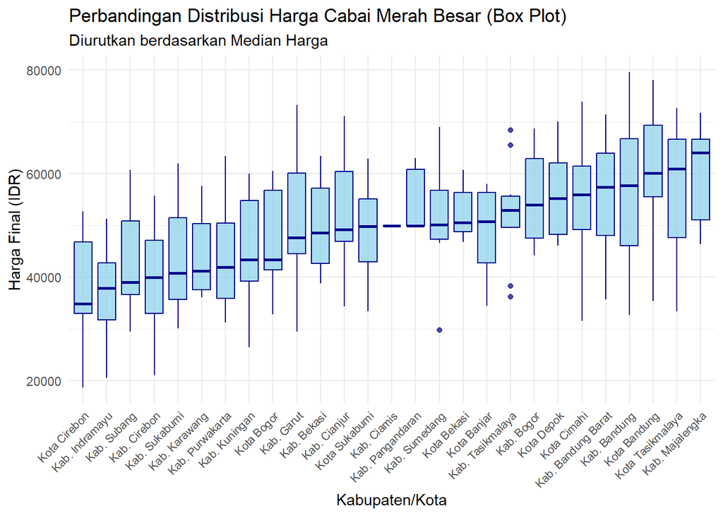

```r
## Box Plot Harga per Kab/Kot
plot_boxplot <- dtpakai %>%
  # Mengurutkan KabKot berdasarkan median harga untuk visualisasi yang lebih baik
  mutate(KabKot = fct_reorder(KabKot, Harga_Final, .fun = median)) %>%
  ggplot(aes(x = KabKot, y = Harga_Final)) +
  geom_boxplot(fill = "skyblue", color = "darkblue", alpha = 0.7) +
  labs(
    title = "Perbandingan Distribusi Harga Cabai Merah Besar (Box Plot)",
    subtitle = "Diurutkan berdasarkan Median Harga",
    x = "Kabupaten/Kota",
    y = "Harga Final (IDR)"
  ) +
  theme_minimal() +
  # Memutar sumbu x agar nama KabKot tidak bertumpuk
  theme(axis.text.x = element_text(angle = 45, hjust = 1, size = 8))

print(plot_boxplot)
```

Boxplot menunjukkan bahwa pasar cabai merah besar di Jawa Barat tidak homogen. Ada kelompok daerah dengan:

- Harga murah dan stabil (Cirebon, Indramayu, Subang) - Harga sedang tetapi fluktuatif (Bogor, Garut, Sumedang)
- Harga tinggi dan bergejolak (Bandung, Cimahi, Tasikmalaya, Majalengka) Informasi ini sangat relevan untuk melihat pola pasar, mengidentifikasi daerah rawan volatilitas harga, dan memahami perbedaan kondisi produksi di tiap wilayah

## b. Plot Time Series

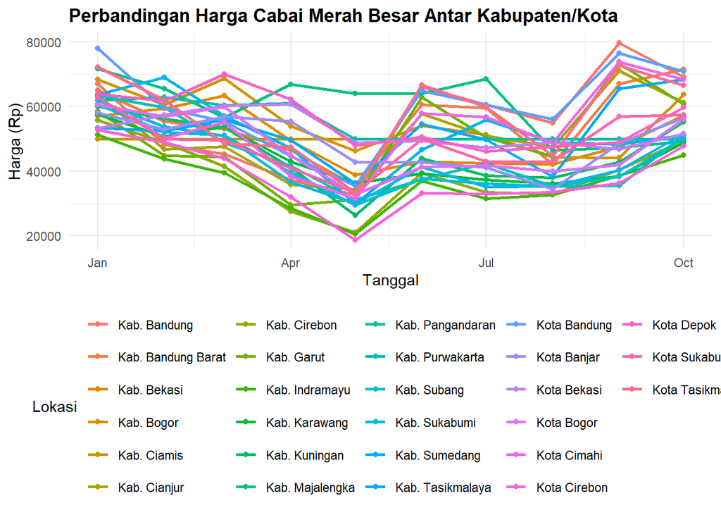

```r
plot_harga <- dtpakai %>%
  ggplot(aes(x = Date, y = Harga_Final, color = KabKot, group = KabKot)) +
  geom_line(linewidth = 1) +
  geom_point(size = 1.5) +
  labs(
    title = "Perbandingan Harga Cabai Merah Besar Antar Kabupaten/Kota",
    x = "Tanggal",
    y = "Harga (Rp)",
    color = "Lokasi"
  ) +
  theme_minimal() +
  theme(legend.position = "bottom", plot.title = element_text(face = "bold"))

print(plot_harga)
```

# 4. Pembentukan Fitur Time Series untuk Clustering

## a. Ubah menjadi Wide Format

```r
df_wide <- dtpakai %>%
  select(KabKot, Date, Harga_Final) %>%
  pivot_wider(
    names_from = KabKot,
    values_from = Harga_Final
  )
df_wide
```

```
## # A tibble: 10 × 28
##    Date       `Kab. Bandung` `Kab. Bandung Barat` `Kab. Bekasi` `Kab. Bogor`
##    <date>              <dbl>                <dbl>         <dbl>        <dbl>
##  1 2025-01-01          67016                65007         57118        68382
##  2 2025-02-01          48197                55357         59444        60577
##  3 2025-03-01          45345                53143         63387        68679
##  4 2025-04-01          37265                46369         49466        53880
##  5 2025-05-01          32705                35645         38788        46348
##  6 2025-06-01          65976                60618         43000        54065
##  7 2025-07-01          60536                59516         42469        51231
##  8 2025-08-01          54941                42097         42190        44195
##  9 2025-09-01          79659                67011         47679        44167
## 10 2025-10-01          69247                71452         57222        63710
## # ℹ 23 more variables: `Kab. Ciamis` <dbl>, `Kab. Cianjur` <dbl>,
## #   `Kab. Cirebon` <dbl>, `Kab. Garut` <dbl>, `Kab. Indramayu` <dbl>,
## #   `Kab. Karawang` <dbl>, `Kab. Kuningan` <dbl>, `Kab. Majalengka` <dbl>,
## #   `Kab. Pangandaran` <dbl>, `Kab. Purwakarta` <dbl>, `Kab. Subang` <dbl>,
## #   `Kab. Sukabumi` <dbl>, `Kab. Sumedang` <dbl>, `Kab. Tasikmalaya` <dbl>,
## #   `Kota Bandung` <dbl>, `Kota Banjar` <dbl>, `Kota Bekasi` <dbl>,
## #   `Kota Bogor` <dbl>, `Kota Cimahi` <dbl>, `Kota Cirebon` <dbl>, …
```

## b. Scaling Data

```r
ts_data <- df_wide %>% select(-Date)

ts_norm <- scale(ts_data)
head(ts_norm)
```

```
##      Kab. Bandung Kab. Bandung Barat Kab. Bekasi Kab. Bogor Kab. Ciamis
## [1,]    0.7247747         0.81885606  0.81658544  1.3675291         NaN
## [2,]   -0.5234326        -0.02307681  1.08631828  0.5374570         NaN
## [3,]   -0.7125971        -0.21624151  1.54356530  1.3991154         NaN
## [4,]   -1.2485190        -0.80725221 -0.07077298 -0.1747778         NaN
## [5,]   -1.5509700        -1.74288828 -1.30903921 -0.9758159         NaN
## [6,]    0.6557947         0.43592928 -0.82059780 -0.1551028         NaN
##      Kab. Cianjur Kab. Cirebon Kab. Garut Kab. Indramayu Kab. Karawang
## [1,]    1.0006417   1.56508236  0.6117574     1.61505807     1.6917622
## [2,]   -0.4146915   0.93708652 -0.3737949     0.78636580     0.8389336
## [3,]   -0.3441827   0.23505979 -0.4003194     0.29624038     1.2060678
## [4,]   -1.3364631  -1.08689351 -1.4713078    -0.93653332    -0.1452930
## [5,]   -1.4670819  -1.69105685 -1.3522693    -1.82883308    -0.9827666
## [6,]    0.5180706   0.04317999  0.9214003     0.01982265    -0.6036758
##      Kab. Kuningan Kab. Majalengka Kab. Pangandaran Kab. Purwakarta Kab. Subang
```

[output cut: 27 more lines]

## c. Pengecekan Missing Value

```r
colSums(is.na(ts_data))
```

```
##       Kab. Bandung Kab. Bandung Barat        Kab. Bekasi         Kab. Bogor
##                  0                  0                  0                  0
##        Kab. Ciamis       Kab. Cianjur       Kab. Cirebon         Kab. Garut
##                  0                  0                  0                  0
##     Kab. Indramayu      Kab. Karawang      Kab. Kuningan    Kab. Majalengka
##                  0                  0                  0                  0
##   Kab. Pangandaran    Kab. Purwakarta        Kab. Subang      Kab. Sukabumi
##                  0                  0                  0                  0
##      Kab. Sumedang   Kab. Tasikmalaya       Kota Bandung        Kota Banjar
##                  0                  0                  0                  0
##        Kota Bekasi         Kota Bogor        Kota Cimahi       Kota Cirebon
##                  0                  0                  0                  0
##         Kota Depok      Kota Sukabumi   Kota Tasikmalaya
##                  0                  0                  0
```

```r
colSums(is.na(ts_norm))
```

```
##       Kab. Bandung Kab. Bandung Barat        Kab. Bekasi         Kab. Bogor
##                  0                  0                  0                  0
##        Kab. Ciamis       Kab. Cianjur       Kab. Cirebon         Kab. Garut
##                 10                  0                  0                  0
##     Kab. Indramayu      Kab. Karawang      Kab. Kuningan    Kab. Majalengka
##                  0                  0                  0                  0
##   Kab. Pangandaran    Kab. Purwakarta        Kab. Subang      Kab. Sukabumi
##                  0                  0                  0                  0
##      Kab. Sumedang   Kab. Tasikmalaya       Kota Bandung        Kota Banjar
##                  0                  0                  0                  0
##        Kota Bekasi         Kota Bogor        Kota Cimahi       Kota Cirebon
##                  0                  0                  0                  0
##         Kota Depok      Kota Sukabumi   Kota Tasikmalaya
##                  0                  0                  0
```

Terdapat missing value pada data yang sudah dinormalisasi yaitu pada Kab. Ciamis, sehingga perlu penanganan

```r
sd_val <- apply(ts_data, 2, sd)
ts_data_clean <- ts_data[ , sd_val != 0]

ts_norm <- scale(ts_data_clean)
ts_norm <- as.matrix(ts_norm)
```

```r
colSums(is.na(ts_norm))
```

```
##       Kab. Bandung Kab. Bandung Barat        Kab. Bekasi         Kab. Bogor
##                  0                  0                  0                  0
##       Kab. Cianjur       Kab. Cirebon         Kab. Garut     Kab. Indramayu
##                  0                  0                  0                  0
##      Kab. Karawang      Kab. Kuningan    Kab. Majalengka   Kab. Pangandaran
##                  0                  0                  0                  0
##    Kab. Purwakarta        Kab. Subang      Kab. Sukabumi      Kab. Sumedang
##                  0                  0                  0                  0
##   Kab. Tasikmalaya       Kota Bandung        Kota Banjar        Kota Bekasi
##                  0                  0                  0                  0
##         Kota Bogor        Kota Cimahi       Kota Cirebon         Kota Depok
##                  0                  0                  0                  0
##      Kota Sukabumi   Kota Tasikmalaya
##                  0                  0
```

Kab. Ciamis dihapus dari proses analisis karena proses imputasi datanya yang masif dengan nilai tunggal telah menghilangkan semua variabilitas harga ($\sigma \approx 0$). Kondisi ini menyebabkan kegagalan dalam Normalisasi Z-Score dan menghasilkan Missing Value ($NaN$). Karena algoritma DTW mengelompokkan berdasarkan pola bentuk deret waktu, deret waktu yang flat ini tidak memberikan sinyal yang valid dan hanya akan membiaskan hasil clustering dari 26 lokasi lainnya.

# 5. Metode Elbow untuk Penentuan Jumlah k menggunakan Jarak DTW

```
## Menghitung k = 2 ...
```

```
## Menghitung k = 3 ...
```

```
## Menghitung k = 4 ...
```

```
## Menghitung k = 5 ...
```

```
## Menghitung k = 6 ...
```

```
## Menghitung k = 7 ...
```

```
## Menghitung k = 8 ...
```

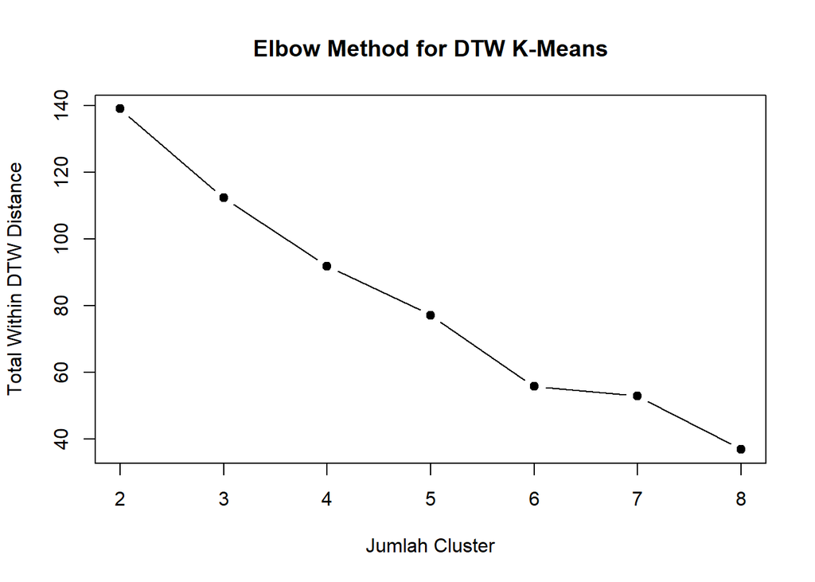

```r
calc_within_dtw <- function(model, data){
  clust <- model@cluster
  centers <- model@centroids
  total <- 0

  for (k in unique(clust)) {
    members <- data[clust == k, , drop = FALSE]
    centroid <- centers[[k]]

    d <- sapply(1:nrow(members), function(i){
      dtw(members[i, ], centroid)$distance
    })

    total <- total + sum(d)
  }
  return(total)
}


# FUNGSI: Elbow Method otomatis untuk DTW K-Means
dtw_elbow <- function(data, kmax = 10){
  within <- numeric(kmax)

  for (k in 2:kmax){
    message("Menghitung k = ", k, " ...")
    km <- tsclust(
      series = data,
      type = "partitional",
      k = k,
      distance = "dtw_basic",
      centroid = "dba"
    )

    within[k] <- calc_within_dtw(km, data)
  }

  plot(2:kmax, within[2:kmax], type="b", pch=19,
       xlab="Jumlah Cluster",
       ylab="Total Within DTW Distance",
       main="Elbow Method for DTW K-Means")

  return(within)
}
elbow_result <- dtw_elbow(ts_norm, kmax = 8)
```

# 6. K-Means Time Series

## a. Konversi Matriks Data Menjadi Daftar Deret Waktu

```r
ts_list <- lapply(1:ncol(ts_norm), function(i) ts_norm[, i])
names(ts_list) <- colnames(ts_norm)
```

## b. Implementasi K-Means Time Series dengan DTW

```r
set.seed(123)

model_final <- tsclust(
  series   = ts_list,
  type     = "partitional",
  k        = 4,
  distance = "dtw_basic",
  centroid = "dba",
  trace    = TRUE
)
```

```
## Iteration 1: Changes / Distsum = 26 / 101.767
## Iteration 2: Changes / Distsum = 1 / 97.25758
## Iteration 3: Changes / Distsum = 0 / 94.51532
##
##  Elapsed time is 0.03 seconds.
```

```r
hasil_cluster <- data.frame(
  Daerah = names(ts_list),
  Cluster = model_final@cluster
)

hasil_cluster
```

```
##                Daerah Cluster
## 1        Kab. Bandung       3
## 2  Kab. Bandung Barat       3
## 3         Kab. Bekasi       2
## 4          Kab. Bogor       2
## 5        Kab. Cianjur       3
## 6        Kab. Cirebon       2
## 7          Kab. Garut       3
## 8      Kab. Indramayu       2
## 9       Kab. Karawang       2
## 10      Kab. Kuningan       2
## 11    Kab. Majalengka       4
## 12   Kab. Pangandaran       1
## 13    Kab. Purwakarta       2
## 14        Kab. Subang       2
## 15      Kab. Sukabumi       2
## 16      Kab. Sumedang       2
## 17   Kab. Tasikmalaya       3
## 18       Kota Bandung       3
## 19        Kota Banjar       1
## 20        Kota Bekasi       1
## 21         Kota Bogor       2
## 22        Kota Cimahi       3
## 23       Kota Cirebon       2
## 24         Kota Depok       1
## 25      Kota Sukabumi       3
## 26   Kota Tasikmalaya       3
```

Hasil clustering menunjukkan bahwa:

- Cluster 1: Kab. Pangandaran, Kota Banjar, Kota Bekasi, dan Kota Depok
- Cluster 2: Kab. Bekasi, Kab. Bogor, Kab. Cirebon, Kab. Indramayu, Kab. Karawang, Kab. Kuningan, Kab. Purwakarta, Kab. Subang, Kab SUkabumi, Kab. Sumedang, Kota Bogor, dan Kota Cirebon
- Cluster 3: Kab. Bandung, Kab. Bandung Barat, Kab. Cianjur, Kab. Garut, Kab. Tasikmalaya, Kota Bandung, Kota Cimahi, Kota Sukabumi, dan Kota Tasikmalaya
- Cluster 4: Kab. Majalengka

```r
hasil_cluster <- dt %>%
  left_join(hasil_cluster, by = c("KabKot" = "Daerah"))

head(hasil_cluster)
```

```
## # A tibble: 6 × 5
##   KabKot       Date       Produk            Harga Cluster
##   <chr>        <date>     <chr>             <dbl>   <int>
## 1 Kab. Bandung 2025-01-01 Cabai Merah Besar 67016       3
## 2 Kab. Bandung 2025-02-01 Cabai Merah Besar 48197       3
## 3 Kab. Bandung 2025-03-01 Cabai Merah Besar 45345       3
## 4 Kab. Bandung 2025-04-01 Cabai Merah Besar 37265       3
## 5 Kab. Bandung 2025-05-01 Cabai Merah Besar 32705       3
## 6 Kab. Bandung 2025-06-01 Cabai Merah Besar 65976       3
```

## c. Plot K-Means Time Series

### Plot Centroid Pola Harga Tiap Cluster

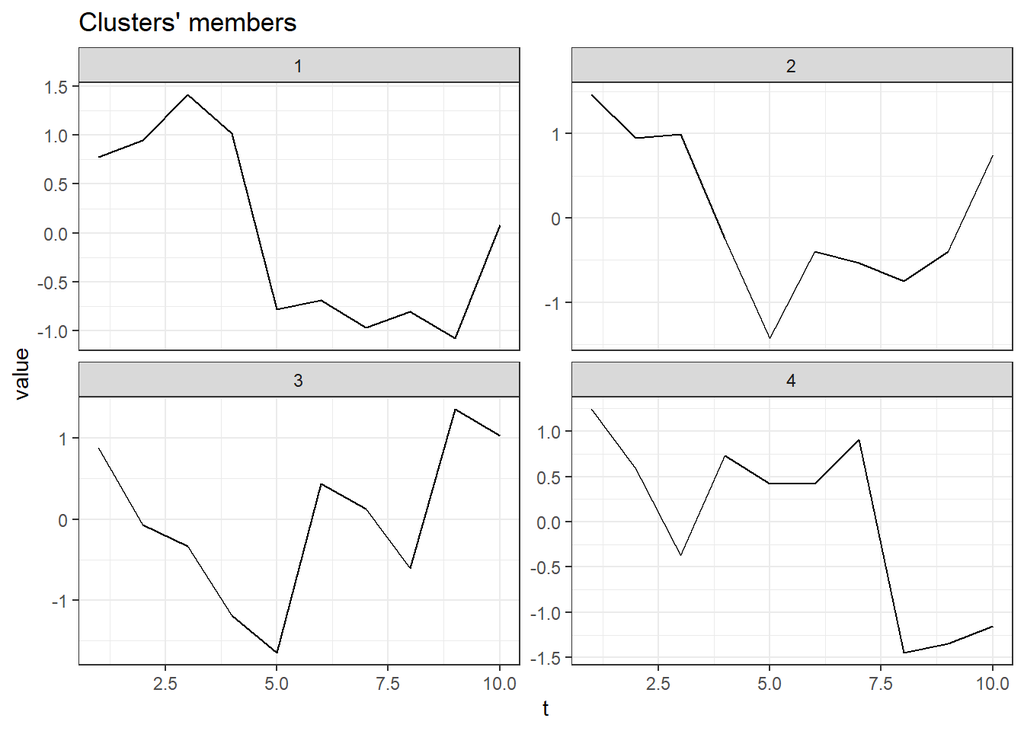

```r
plot(model_final, type = "centroids",
     main = "Centroid Pola Harga Tiap Cluster")
```

Hasil clustering menunjukkan bahwa harga produksi cabai merah besar antar kabupaten/kota membentuk empat pola utama. Cluster 1 ditandai oleh kenaikan harga di awal periode yang kemudian mengalami penurunan tajam di pertengahan sebelum sedikit pulih di akhir, mencerminkan adanya tekanan harga akibat lonjakan pasokan. Cluster 2 memiliki harga awal yang stabil dan relatif tinggi, namun mengalami koreksi besar di tengah periode dan pulih perlahan, menggambarkan wilayah dengan fluktuasi harga yang sensitif terhadap perubahan pasokan. Cluster 3 menunjukkan penurunan harga pada awal periode yang kemudian diikuti rebound kuat pada pertengahan hingga akhir, mengindikasikan pola musiman di mana harga naik saat pasokan mulai menurun. Sementara itu, Cluster 4 memperlihatkan pola fluktuatif—harga turun, kemudian naik, lalu jatuh tajam di akhir yang menunjukkan dinamika pasokan yang berubah-ubah. Secara keseluruhan, keempat klaster ini mencerminkan variasi karakteristik pasar cabai merah besar di tiap kabupaten/kota.

### Plot K-Means Time Series

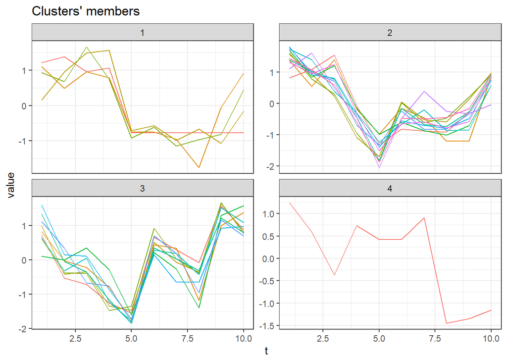

```r
plot(model_final, type = "series",
     main = "Hasil Clustering Time Series 26 Daerah")
```

Keempat cluster memperlihatkan bahwa setiap daerah memiliki dinamika harga yang berbeda, tetapi mayoritas mengikuti pola yang mirip (dominan pada Klaster 2 dan 3). Pola penurunan dan kenaikan yang hampir serempak di banyak cluster menunjukkan bahwa harga cabai merah besar sangat dipengaruhi faktor musiman dan regional, sementara beberapa daerah memiliki pola harga yang menonjol dan berbeda sendiri (seperti pada Klaster 4).

# 7. Silhouette Plot

```r
dist_dtw <- proxy::dist(ts_list, method = "DTW")

sil <- silhouette(model_final@cluster, dist_dtw)
summary(sil)
```

```
## Silhouette of 26 units in 4 clusters from silhouette.default(x = model_final@cluster, dist = dist_dtw) :
##  Cluster sizes and average silhouette widths:
##         4        12         9         1
## 0.1798545 0.1705279 0.2641393 0.0000000
## Individual silhouette widths:
##    Min. 1st Qu.  Median    Mean 3rd Qu.    Max.
## -0.1070  0.1039  0.2313  0.1978  0.2779  0.3757
```

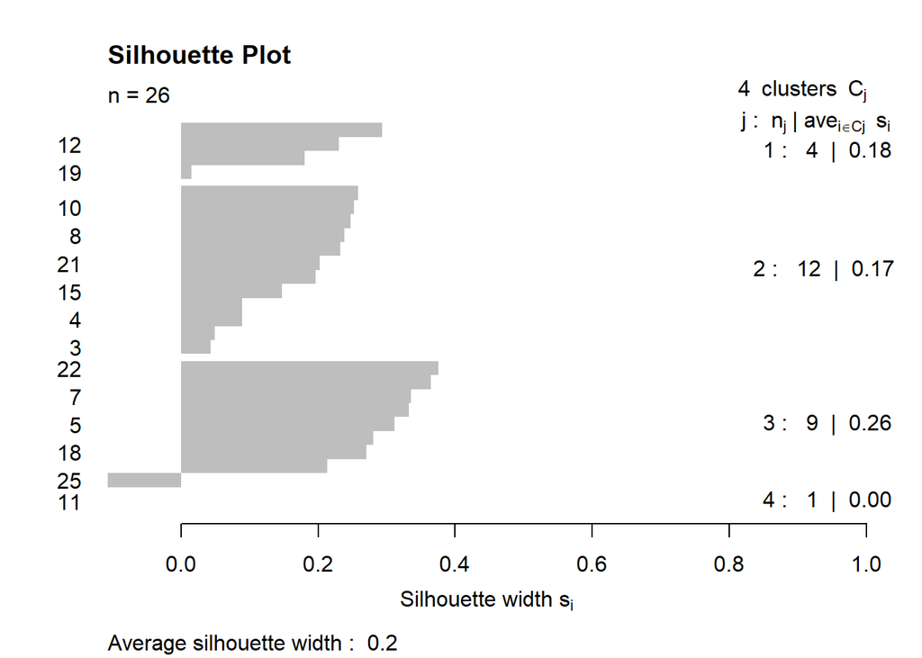

```r
plot(sil, border = NA, main = "Silhouette Plot")
```

Nilai silhouette sebesar 0.2 menunjukkan bahwa struktur cluster masih lemah, tetapi pola harga yang terbentuk tetap memberikan pemisahan yang cukup informatif. cluster 3 adalah klaster paling stabil, sedangkan cluster 4 menandakan adanya satu daerah yang sangat berbeda dari daerah lainnya.

**Kesimpulan:**

Secara keseluruhan, hasil analisis menunjukkan bahwa harga cabai merah besar di Jawa Barat cenderung bergerak serempak antar kabupaten/kota dengan pola penurunan pada triwulan II dan kenaikan kembali menjelang akhir tahun, di mana wilayah perkotaan dan beberapa kabupaten tertentu membentuk kantong harga yang relatif lebih tinggi dibanding daerah lain. Penerapan clustering time series dengan DTW dan k-means menghasilkan empat kelompok pola pergerakan harga, dengan mayoritas daerah masuk ke dalam dua cluster utama yang mencerminkan pola musiman yang mirip, sementara satu daerah muncul sebagai outlier dengan dinamika harga yang jauh berbeda. Meskipun kualitas pemisahan cluster masih terbatas (silhouette relatif rendah), hasil ini tetap memberikan gambaran bahwa struktur harga cabai merah besar di Jawa Barat kuat dipengaruhi faktor musiman, karakteristik wilayah (produksi vs konsumsi), serta kemungkinan perbedaan kondisi pasokan dan distribusi, sehingga dapat menjadi dasar awal untuk perumusan kebijakan pemantauan dan stabilisasi harga yang lebih terarah. Daerah pada cluster dengan harga tinggi dan volalitas besar perlu prioritas pengawasan pasokan dan integritas dengan kebijakan stabilisasi harga. Sedangkan patokan atau tolak ukur dapat dilihat dari daerah dengan cluster yang relatif stabil dalam perencanaan distribusi tanam bagi daerah lain.